# Final Project: Model Monitoring

## Roselyn Isimeto

**Problem Statement:**

The objective is to analyze the relationship between advertising expenditures across different media sources, including TV, Radio, and Newspaper, and their impact on sales performance. The goal is to determine the optimal allocation of advertising budgets across these channels to maximize sales revenue. By examining the correlation between advertising expenditures and sales, the company aims to identify the most effective advertising strategies and make data-driven decisions to improve its marketing efforts. The insights gained from this analysis will enable the company to optimize resource allocation and develop a robust advertising strategy that aligns with its sales objectives.

Additionally, the business recognizes the need for ongoing model monitoring to ensure the effectiveness and accuracy of the advertising expenditure-to-sales relationship. By implementing a comprehensive model monitoring system, the company aims to continuously evaluate the performance of the advertising strategy and identify any potential deviations or shifts in the relationship. This will enable timely adjustments and optimizations to maintain the desired level of sales revenue.

## Connect to the workspace

```python
pip install --upgrade azureml-sdk
```

```python
# Handle to the workspace
from azure.ai.ml import MLClient
from azure.ai.ml.entities import Data
from azure.ai.ml.constants import AssetTypes

# Authentication package
from azure.identity import DefaultAzureCredential

credential = DefaultAzureCredential()


from azure.ai.ml import command, Input

from azure.ai.ml.entities import (
    ManagedOnlineEndpoint,
    ManagedOnlineDeployment,
    Model,
    CodeConfiguration
)

from azure.storage.blob import BlobServiceClient
```

## Create a compute resource to run the jobs

```python
# Get a handle to the workspace
ml_client = MLClient(
    credential=credential,
    subscription_id="bd3b00cc-6c29-4334-a410-a29ae27f4b6e", #Provide your subscription ID as shown in the above screenshot
    resource_group_name="finpj", #Provide your Resource Group as shown in the above screenshot
    workspace_name="finpro",
)
```

#### Create a compute resource to run the job

```python
from azure.ai.ml.entities import AmlCompute

# Name assigned to the compute cluster
cpu_compute_target = "cpu-cluster"

try:
    # let's see if the compute target already exists
    cpu_cluster = ml_client.compute.get(cpu_compute_target)
    print(
        f"You already have a cluster named {cpu_compute_target}, we'll reuse it as is."
    )

except Exception:
    print("Creating a new cpu compute target...")

    # Let's create the Azure ML compute object with the intended parameters
    cpu_cluster = AmlCompute(
        name=cpu_compute_target,
        # Azure ML Compute is the on-demand VM service
        type="amlcompute",
        # VM Family
        size="Standard_DS3_v2",
        # Minimum running nodes when there is no job running
        min_instances=0,
        # Nodes in cluster
        max_instances=1,
        # How many seconds will the node running after the job termination
        idle_time_before_scale_down=180,
        # Dedicated or LowPriority. The latter is cheaper but there is a chance of job termination
        tier="Dedicated",
    )

    # Now, we pass the object to MLClient's create_or_update method
    cpu_cluster = ml_client.compute.begin_create_or_update(cpu_cluster).result()

print(
    f"AMLCompute with name {cpu_cluster.name} is created, the compute size is {cpu_cluster.size}"
)
```

```
Creating a new cpu compute target...
AMLCompute with name cpu-cluster is created, the compute size is STANDARD_DS3_V2
```

## Configure and submit your training job

#### Prepare the training script:

```python
# To use the training script, first create a directory where you will store the file.
import os

src_dir = "./src"
os.makedirs(src_dir, exist_ok=True)
```

#### Define training job:

```python
%%writefile {src_dir}/main.py
import os
import argparse
import pandas as pd
import mlflow
import mlflow.sklearn
from sklearn.ensemble import GradientBoostingRegressor
from sklearn.metrics import classification_report
from sklearn.model_selection import train_test_split

def main():
    """Main function of the script."""

    # input and output arguments
    parser = argparse.ArgumentParser()
    parser.add_argument("--data", type=str, help="path to input data")
    parser.add_argument("--test_train_ratio", type=float, required=False, default=0.25)
    parser.add_argument("--n_estimators", required=False, default=100, type=int)
    parser.add_argument("--learning_rate", required=False, default=0.1, type=float)
    parser.add_argument("--registered_model_name", type=str, help="model name")
    args = parser.parse_args()

    # Start Logging
    mlflow.start_run()

    # enable autologging
    mlflow.sklearn.autolog()

    ###################
    #<prepare the data>
    ###################
    print(" ".join(f"{k}={v}" for k, v in vars(args).items()))

    print("input data:", args.data)

    df = pd.read_csv(args.data) #header=1, index_col=0

    mlflow.log_metric("num_samples", df.shape[0])
    mlflow.log_metric("num_features", df.shape[1] - 1)

    # Renaming the label column
    df.rename(columns={"Sales": "sales"}, inplace=True)

    ####################
    #</prepare the data>
    ####################

    # split the data into training and testing sets
    train_df, test_df = train_test_split(
        df,
        test_size=args.test_train_ratio, random_state=42
    )


    # Extracting the label column
    y_train = train_df.pop("sales")

    # convert the dataframe values to array
    X_train = train_df.values

    # Extracting the label column
    y_test = test_df.pop("sales")

    # convert the dataframe values to array
    X_test = test_df.values


    ##################
    #<train the model>
    ##################
    # Extracting the label column


    print(f"Training with data of shape {X_train.shape}")

    gbr = GradientBoostingRegressor(
        n_estimators=args.n_estimators,
        learning_rate=args.learning_rate
    )

    gbr.fit(X_train, y_train)

    rmse = gbr.score(X_test, y_test)

    mlflow.log_metric("RMSE", float(rmse))


    ###################
    #</train the model>
    ###################

    ##########################
    #<save and register model>
    ##########################
    # Registering the model to the workspace
    print("Registering the model via MLFlow")
    mlflow.sklearn.log_model(
        sk_model=gbr,
        registered_model_name=args.registered_model_name,
        artifact_path=args.registered_model_name,
    )

    # Saving the model to a file
    print("Saving the model via MLFlow")
    mlflow.sklearn.save_model(
        sk_model=gbr,
        path=os.path.join(args.registered_model_name, "trained_model"),
    )
    ###########################
    #</save and register model>
    ###########################

    # Stop Logging
    mlflow.end_run()

if __name__ == "__main__":
    main()
```

```
Overwriting ./src/main.py
```

```python
from azure.ai.ml import command
from azure.ai.ml import Input

registered_model_name = "advert_sales_model"

job = command(
    inputs=dict(
        data=Input(
            type="uri_file",
            path="azureml:advertising_sales_data:1", # The path to the input data file,
        ),
        test_train_ratio=0.3,
        learning_rate=0.1,
        registered_model_name=registered_model_name,
    ),
    code="./src/",  # location of source code
    command="python main.py --data ${{inputs.data}} --test_train_ratio ${{inputs.test_train_ratio}} --learning_rate ${{inputs.learning_rate}} --registered_model_name ${{inputs.registered_model_name}}",
    environment="AzureML-sklearn-1.0-ubuntu20.04-py38-cpu@latest",
    compute="cpu-cluster", #delete this line to use serverless compute
    # Specify the name of the experiment for the job
    experiment_name="advertising_exper_test",
    display_name="optimal allocation of advertising budgets",
)
```

#### Submit the job:

```python
# ml_client.create_or_update will create a new job if it does not exist or update the existing job if it does
returned_job= ml_client.create_or_update(job)

# stream the output and wait until the job is finished
#ml_client.jobs.stream(returned_job.name)
#returned_job = ml_client.jobs.get(name=returned_job.name)
```

[output not shown]

```python
from PIL import Image
from IPython.display import display
```

[figure not shown]

```python
img = Image.open('trainedmodel.png')
display(img)
```

[figure not shown]

```python
img = Image.open('job.png')
display(img)
```

[figure not shown]

```python
img = Image.open('model-artifact.png')
display(img)
```

Immediately the training job is successfully completed, an ML model will be registered in the workspace, as a result of the training

[figure not shown]

```python
img = Image.open('overviewOfJob.png')
display(img)
```

## Find and register the model

Registering the model. Registering your model before deployment is a recommended best practice.

```python
# Import the necessary libraries
from azure.ai.ml.entities import Model
from azure.ai.ml.constants import AssetTypes

# Provide the model details, including the
# path to the model files, if you've stored them locally.



mlflow_model = Model(
   path="./advert_sales_model",
   #Path to the root directory of the model.
   type=AssetTypes.MLFLOW_MODEL,
   name="advert_sales_model_v2",
   description="MLflow Model created for allocation of adverts budget tasks.",
)
```

```python
# Register the model
registered_model=ml_client.models.create_or_update(model= mlflow_model)
```

[figure not shown]

```python
img = Image.open('overviewOfJob.png')
display(img)
```

## Create Online Endpoint

**import required libraries**

```python
# import required libraries
from azure.ai.ml.entities import (
    ManagedOnlineEndpoint,
    ManagedOnlineDeployment,
    Model,
    Environment,
    CodeConfiguration,
)
from azure.ai.ml.constants import AssetTypes
```

#### Configure the endpoint:

```python
# Importing the required modules
import random
import string

# Creating a unique endpoint name by including a random suffix

# Defining a list of allowed characters for the endpoint suffix
allowed_chars = string.ascii_lowercase + string.digits

# Generating a random 5-character suffix for the endpoint name by choosing
# characters randomly from the list of allowed characters
endpoint_suffix = "".join(random.choice(allowed_chars) for x in range(5))

# Creating the final endpoint name by concatenating a prefix string
# with the generated suffix string
online_endpoint_name = "salesadvert-endpoint-" + endpoint_suffix
```

```python
print(f"Endpoint name: {online_endpoint_name}")
```

```
Endpoint name: salesadvert-endpoint-144rs
```

```python
endpoint = ManagedOnlineEndpoint(
    name=online_endpoint_name,
    # Name of the endpoint, should be unique within your deployment
    description="An online endpoint serving an MLflow model for allocation of advertising budgets task",
    # A string describing the purpose of the endpoint
    auth_mode="key",
    # Authentication mode to use for the endpoint (in this case, using an API key)
    tags={"allocating": "advetising budgets"},
    # A dictionary of key-value pairs that can be used to tag the endpoint
)
```

#### Create the endpoint:

```python
endpoint = ml_client.online_endpoints.begin_create_or_update(endpoint).result()
```

Once you've created the endpoint, you can retrieve it as follows:****

```python
endpoint = ml_client.online_endpoints.get(name=online_endpoint_name)

print(
    f'Endpoint "{endpoint.name}" with provisioning state "{endpoint.provisioning_state}" is retrieved'
)
```

```
Endpoint "salesadvert-endpoint-144rs" with provisioning state "Succeeded" is retrieved
```

## Create a blue deployment

#### Curating the deployment script:

```python
%%writefile {src_dir}/score.py

# Import necessary libraries and modules
import logging
import os
import json
import joblib
import numpy
import mlflow
from io import StringIO
from mlflow.pyfunc.scoring_server import infer_and_parse_json_input, predictions_to_json

######################LOGGER#####################
# Set up Azure logging
import logging
from logging import Logger
from opencensus.ext.azure.log_exporter import AzureLogHandler

# Connect to Application Insights and set logging level to INFO
application_insights_connection_string= 'InstrumentationKey=f4a91cfe-cc17-4542-ac74-b594946f59ad;IngestionEndpoint=https://eastus2-3.in.applicationinsights.azure.com/;LiveEndpoint=https://eastus2.livediagnostics.monitor.azure.com/'
handler = AzureLogHandler(
connection_string=application_insights_connection_string)
logger = logging.getLogger()
logger.addHandler(handler)
logger.setLevel(logging.INFO)

####################################################

# Define the init() function to load the MLflow model
def init():
    global model
    global input_schema
    # "model" is the path of the mlflow artifacts when the model was registered. For automl
    # models, this is generally "mlflow-model".

    #files=os.listdir(os.getenv("AZUREML_MODEL_DIR"))
    #print("files in {}:{}".format(os.getenv("AZUREML_MODEL_DIR"),files))

    model_path = os.path.join(os.getenv("AZUREML_MODEL_DIR"), "advert_sales_model")  #("model/model.pkl") #./visa_best_model/visa-approval_decisiontree_model

    # deserialize the model file back into a sklearn model
    #model = joblib.load(model_path)

    logger.info(f"loading model from {model_path}")
    model = mlflow.pyfunc.load_model(model_path)
    input_schema = model.metadata.get_input_schema()



# Define the run() function to make predictions using the loaded model
def run(raw_data):
    # Parse input data
    json_data = json.loads(raw_data)
    logger.info(json_data)
    if "input_data" not in json_data.keys():
        raise Exception("Request must contain a top level key named 'input_data'")
    serving_input = json.dumps(json_data["input_data"])
    data = infer_and_parse_json_input(serving_input, input_schema)

    # Make predictions
    predictions = model.predict(data)

    # Log the input data and predictions to Azure
    logger.info("Data:{0},Predictions:{1}".format(str(data),str(predictions)))

    # Convert predictions to JSON format and return
    result = StringIO()
    predictions_to_json(predictions, result)
    return result.getvalue()
```

```
Overwriting ./src/score.py
```

#### Configure the deployment:

```python
from azure.ai.ml.entities import ManagedOnlineDeployment
from azureml.core import Environment



#env.docker.enabled = True
#env.docker.base_image = 'mcr.microsoft.com/azureml/openmpi3.1.2-cuda10.1-cudnn7-ubuntu18.04'


# Create a new deployment with name "blue"
blue_deployment = ManagedOnlineDeployment(
    name="blue",
    # Use the previously generated endpoint name
    endpoint_name=online_endpoint_name,
    # Use the registered model
    model = registered_model,   # Choose the latest version of our registered model for deployment

    # Use the latest environment named "machine_learning_E2E"
    environment= "AzureML-sklearn-1.0-ubuntu20.04-py38-cpu@latest",  #"env.docker.base_image:latest", #"mcr.microsoft.com/azureml/openmpi4.1.0-ubuntu20.04:latest", #"AzureML-sklearn-1.0-ubuntu20.04-py38-cpu@latest",
    #environment= "mcr.microsoft.com/azureml/openmpi4.1.0-ubuntu20.04:latest",
    # Use the code in the "./src" directory and the "score.py" script
    code_configuration=CodeConfiguration(
        code="./src", scoring_script="score.py"
    ),
    # Use a single instance of type "Standard_DS3_v2"
    instance_type="Standard_E2s_v3",  #"Standard_DS3_v2",  #Standard_E16s_v33
    instance_count=1,
    # Enable Application Insights for the deployment   train_src_dir
    app_insights_enabled=True,
)
```

#### Create the deployment:

```python
ml_client.online_deployments.begin_create_or_update(blue_deployment).result()
# create the online deployment
```

```
Check: endpoint salesadvert-endpoint-144rs exists
```

```
........................................................................
```

[output not shown]

#### Check the status of the endpoint

**You can check the status of the endpoint to see whether the model was deployed without error:**

```python
# return an object that contains metadata for the endpoint
endpoint = ml_client.online_endpoints.get(name=online_endpoint_name)

# print a selection of the endpoint's metadata
print(
    f"Name: {endpoint.name}\nStatus: {endpoint.provisioning_state}\nDescription: {endpoint.description}"
)
```

```
Name: salesadvert-endpoint-144rs
Status: Succeeded
Description: An online endpoint serving an MLflow model for allocation of advertising budgets task
```

```python
# existing traffic details
print(endpoint.traffic)

# Get the scoring URI
print(endpoint.scoring_uri)
```

```
{'blue': 0}
https://salesadvert-endpoint-144rs.eastus2.inference.ml.azure.com/score
```

```python
# test the blue deployment with the sample data

import json

prediction = ml_client.online_endpoints.invoke(
    endpoint_name=online_endpoint_name,
    deployment_name="blue",
    request_file="./sample-request-sklearn.json",

)

#prediction = json.loads(prediction)
#prediction_dict = json.loads(prediction)
#prediction_dict['predictions']
```

```python
connection_string='DefaultEndpointsProtocol=https;AccountName=finpro7484630901;AccountKey=DkraSewt3Ab2rBpgGw07WwO9hOQz9h0bttWY9fJETGtFOXcVh/VTJu38LbXhkS31Rgkm2U9cgfSk+AStfLZ2NQ==;EndpointSuffix=core.windows.net'
```

```python
# Convert the string representation of predictions to a Python data structure
import ast
model_predictions_azure_list = ast.literal_eval(prediction)
```

```python
# Access the converted Python data structure
model_predictions_azure_list_2 = ast.literal_eval(model_predictions_azure_list)
model_predictions_azure_list_2
```

```
{'predictions': [21.3104217773912,
  26.91177669875793,
  21.3104217773912,
  15.929318692164093,
  17.104454755512567,
  21.23053699230288,
  26.91177669875793,
  21.23053699230288,
  15.922004177564746,
  17.104454755512567,
  21.759808410293665,
  26.97438820266971,
  21.966277741861113,
  15.783997280836717,
  17.13316572912153,
  23.590891700382098,
  26.97438820266971,
  24.439728450164697,
  15.922004177564746]}
```

```python
# Access the converted Python data structure
model_predictions_azure_list_2 = ast.literal_eval(model_predictions_azure_list)
model_predictions_azure_list_2
```

```
{'predictions': [21.3104217773912,
  26.91177669875793,
  21.3104217773912,
  15.929318692164093,
  17.104454755512567,
  21.23053699230288,
  26.91177669875793,
  21.23053699230288,
  15.922004177564746,
  17.104454755512567,
  21.759808410293665,
  26.97438820266971,
  21.966277741861113,
  15.783997280836717,
  17.13316572912153,
  23.590891700382098,
  26.97438820266971,
  24.439728450164697,
  15.922004177564746]}
```

```python
# Extract the predicted values from the dictionary and convert them to a list or array-like object
predicted_values = model_predictions_azure_list_2['predictions']
```

## Target Check

This is a very critical check especially when the ground truth is delayed. By comparing the distribution of the predictions with the target present in the training data, we can flag deviations beyond expected amount of variation.

#### Compare the distribution of predictions from the endpoint with the distribution of the target in the training data (Advertising.csv)

```python
#Access the training data
import pandas as pd
training_data = pd.read_csv("Advertising_Sales.csv")
```

```python
pip install seaborn
```

[output not shown]

```python
#General imports required for testing
import json
import ast

import logging

import pandas as pd
import matplotlib.pyplot as plt
import seaborn as sns

from scipy.stats import ks_2samp, chi2_contingency, ttest_rel
```

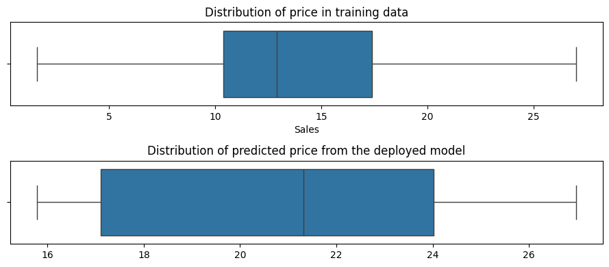

```python
#predicted_values = prediction_dict['predictions']

plt.figure(figsize=(9, 4))
plt.subplot(211)
sns.boxplot(x='Sales', data=training_data)
plt.title("Distribution of price in training data")
plt.subplot(212)
sns.boxplot(x=predicted_values)
plt.title("Distribution of predicted price from the deployed model")
plt.tight_layout()
```

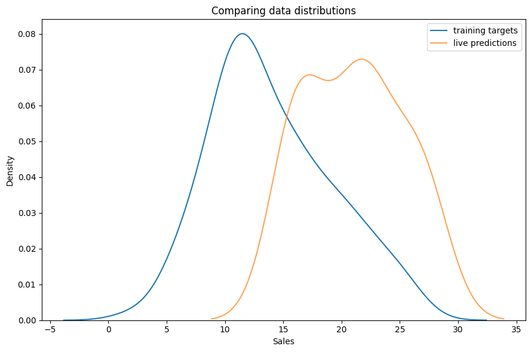

```python
plt.figure(figsize=(9, 6))
sns.kdeplot(x='Sales', data=training_data, label='training targets')
sns.kdeplot(x=predicted_values, label='live predictions', alpha=.7)
plt.legend()
plt.title('Comparing data distributions')
plt.tight_layout()
```

#### Kolmogorov-Smirnov test:

Plot:

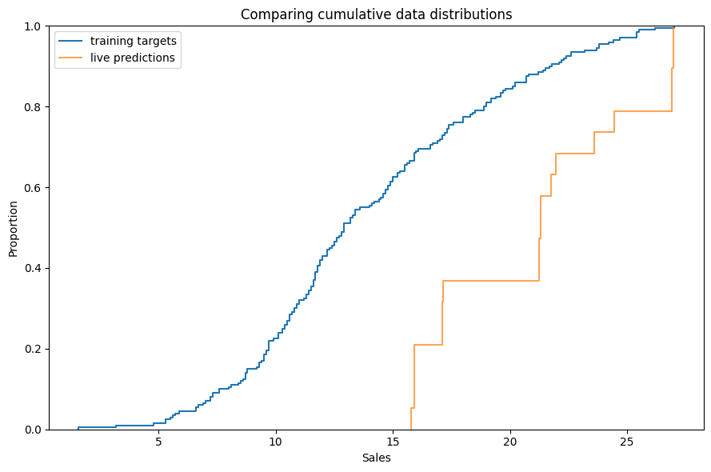

```python
plt.figure(figsize=(9, 6))
sns.ecdfplot(x='Sales', data=training_data, label='training targets')
sns.ecdfplot(x=predicted_values, label='live predictions', alpha=.7)
plt.legend()
plt.title('Comparing cumulative data distributions')
plt.tight_layout()
```

K-S Test:

```python
statistic, p_value = ks_2samp(
            training_data["Sales"].values,
            predicted_values
)
```

```python
p_value
```

```
5.193813228183016e-08
```

## Data Drift

We define data drift as the phenomenon of deviation or changes occurring between the distribution or characteristics of the training features and the corresponding live features used for real-time predictions or analysis. It indicates a shift in the underlying data generating process and can have significant implications for the performance and reliability of machine learning models or data-driven systems.

Note: Use "advertising_synthetic.csv" to check for data drift

```python
sample = pd.read_csv("advertising_synthetic.csv")
```

```python
sample.info()
```

```
<class 'pandas.core.frame.DataFrame'>
RangeIndex: 49 entries, 0 to 48
Data columns (total 4 columns):
 #   Column     Non-Null Count  Dtype
---  ------     --------------  -----
 0   TV         49 non-null     float64
 1   Radio      49 non-null     float64
 2   Newspaper  49 non-null     float64
 3   Sales      49 non-null     float64
dtypes: float64(4)
memory usage: 1.7 KB
```

```python
threshold = 0.05
features_with_data_drift = []
```

```python
target = "sales"
numeric_features = ['TV', 'Radio', 'Newspaper']
categorical_features = []
```

```python
for k, feature in enumerate(sample.columns):
    # Check if the feature is numeric
    # Perform the Kolmogorov-Smirnov test between the corresponding feature in the training and sample data
    if feature in numeric_features:
        statistic, p_value = ks_2samp(
            training_data[feature].values,
            sample[feature].values
        )

        if p_value < threshold:
            features_with_data_drift.append(feature)
    # Check if the feature is categorical
    # Perform the chi-squared test between the corresponding feature in the training and sample data
    elif feature in categorical_features:
        statistic, p_value, dof, expected = chi2_contingency(
            pd.crosstab(
                training_data[feature],
                sample[feature]
            ).values
        )
        # Add the feature to the list of features with data drift
        if p_value < threshold:
            features_with_data_drift.append(feature)
```

```python
features_with_data_drift
```

```
[]
```

## Model Drift

To confirm model drift, we compare the ground truth of live data with the predictions from the deployed model. This involves extracting samples where the predictions and ground truth are compared, followed by conducting a statistical test to determine if there is a significant difference between the model predictions and the ground truth.

For regression problems where the ground truth is readily available, we can compare the model's performance on a random sample with the ground truth observed in that sample. This comparison utilizes a paired two-sample t-test since the exact same sample is presented to both the deployed model and the ground truth. If the ground truth is not immediately available, we can estimate it manually and then compare the model's performance on the random sample with the manually estimated ground truth, again employing a paired two-sample t-test. In cases where manual estimation is not possible, we combine the ground truth (when available) with the predictions on the sample and perform a paired two-sample t-test for comparison.

Note: Use "advertising_ground_truth.csv" to check for Model drift

```python
ground_truth = pd.read_csv('advertising_ground_truth.csv')
```

Note: on the basis of p-value outcome state if there is significance difference between the model predictions and ground truth.

```python
ground_truth_prices = pd.read_csv('advertising_ground_truth.csv')
```

```python
# Perform a paired two-sample t-test
two_sample_ttest = ttest_rel(predicted_values, ground_truth_prices['Sales'])
```

```python
two_sample_ttest.pvalue
```

```
4.9589799436460955e-05
```

Note: on the basis of p-value outcome state if there is significance difference between the model predictions and ground truth.

Since the p value is less than 0.05, we conclude that there is a significant difference between the model predictions and the ground truth.

# Note: Refer to MLS and LVS Week8 to perform this section of the project

```python
%%writefile {src_dir}/score.py

import os
import logging
import json
import numpy
import joblib


def init():
    """
    This function is called when the container is initialized/started, typically after create/update of the deployment.
    You can write the logic here to perform init operations like caching the model in memory
    """
    global model
    # AZUREML_MODEL_DIR is an environment variable created during deployment.
    # It is the path to the model folder (./azureml-models/$MODEL_NAME/$VERSION)
    # Please provide your model's folder name if there is one
    model_path = os.path.join(
        os.getenv("AZUREML_MODEL_DIR"), "./adSales/advert_sales_model/model.pkl"
    )
    # deserialize the model file back into a sklearn model
    model = joblib.load(model_path)
    logging.info("Init complete")


def run(raw_data):
    """
    This function is called for every invocation of the endpoint to perform the actual scoring/prediction.
    In the example we extract the data from the json input and call the scikit-learn model's predict()
    method and return the result back
    """
    logging.info("model 1: request received")
    data = json.loads(raw_data)["data"]
    data = numpy.array(data)
    result = model.predict(data)
    logging.info("Request processed")
    return result.tolist()
```

```python
%%writefile {src_dir}/score.py

# Import necessary libraries and modules
import logging
import os
import json
import joblib
import numpy
import mlflow
from io import StringIO
from mlflow.pyfunc.scoring_server import infer_and_parse_json_input, predictions_to_json

######################LOGGER#####################
# Set up Azure logging
import logging
from logging import Logger
from opencensus.ext.azure.log_exporter import AzureLogHandler

# Connect to Application Insights and set logging level to INFO
application_insights_connection_string= 'InstrumentationKey=f4a91cfe-cc17-4542-ac74-b594946f59ad;IngestionEndpoint=https://eastus2-3.in.applicationinsights.azure.com/;LiveEndpoint=https://eastus2.livediagnostics.monitor.azure.com/'
handler = AzureLogHandler(
connection_string=application_insights_connection_string)
logger = logging.getLogger()
logger.addHandler(handler)
logger.setLevel(logging.INFO)

####################################################

# Define the init() function to load the MLflow model
def init():
    global model
    global input_schema
    # "model" is the path of the mlflow artifacts when the model was registered. For automl
    # models, this is generally "mlflow-model".

    files=os.listdir(os.getenv("AZUREML_MODEL_DIR"))
    print("files in {}:{}".format(os.getenv("AZUREML_MODEL_DIR"),files))

    model_path = os.path.join(os.getenv("AZUREML_MODEL_DIR"), "./adSales/advert_sales_model/model.pkl")  #("model/model.pkl") #./visa_best_model/visa-approval_decisiontree_model
    logger.info(f"loading model from {model_path}")
    model = mlflow.pyfunc.load_model(model_path)
    input_schema = model.metadata.get_input_schema()

# Define the run() function to make predictions using the loaded model
def run(raw_data):
    # Parse input data
    json_data = json.loads(raw_data)
    logger.info(json_data)
    if "input_data" not in json_data.keys():
        raise Exception("Request must contain a top level key named 'input_data'")
    serving_input = json.dumps(json_data["input_data"])
    data = infer_and_parse_json_input(serving_input, input_schema)

    # Make predictions
    predictions = model.predict(data)

    # Log the input data and predictions to Azure
    logger.info("Data:{0},Predictions:{1}".format(str(data),str(predictions)))

    # Convert predictions to JSON format and return
    result = StringIO()
    predictions_to_json(predictions, result)
    return result.getvalue()
```

```
Overwriting ./src/score.py
```

```python
import urllib.request
import json
import os
import ssl

def allowSelfSignedHttps(allowed):
    # bypass the server certificate verification on client side
    if allowed and not os.environ.get('PYTHONHTTPSVERIFY', '') and getattr(ssl, '_create_unverified_context', None):
        ssl._create_default_https_context = ssl._create_unverified_context

allowSelfSignedHttps(True) # this line is needed if you use self-signed certificate in your scoring service.

# Request data goes here
# The example below assumes JSON formatting which may be updated
# depending on the format your endpoint expects.
# More information can be found here:
# https://docs.microsoft.com/azure/machine-learning/how-to-deploy-advanced-entry-script
data =  {
  "input_data": [
      [641.7, 32.8, 58.7],
      [752.0, 65.2, 44.9],
      [863.7, 32.8, 58.7],
      [107.7, 62.4, 48.7],
      [119.7, 82.8, 68.2],
      [610.7, 31.8, 55.7],
      [717.0, 61.2, 45.9],
      [810.7, 31.8, 55.7],
      [101.7, 61.4, 46.7],
      [110.7, 81.8, 66.2],
      [600.7, 33.8, 57.7],
      [700.0, 63.2, 42.9],
      [804.7, 34.8, 52.7],
      [101.7, 65.4, 45.7],
      [111.7, 85.8, 64.2],
      [628.7, 36.8, 56.7],
      [720.0, 68.2, 41.9],
      [821.7, 39.8, 51.7],
      [101.7, 67.4, 46.7]
    ]

}


body = str.encode(json.dumps(data))

url = 'https://salesadvert-endpoint-damv8.eastus2.inference.ml.azure.com/score'
# Replace this with the primary/secondary key or AMLToken for the endpoint
api_key = 'oALkUMBDxcAuQ9BugcDM0jcc7KYlJX9L'
if not api_key:
    raise Exception("A key should be provided to invoke the endpoint")

# The azureml-model-deployment header will force the request to go to a specific deployment.
# Remove this header to have the request observe the endpoint traffic rules
headers = {'Content-Type':'application/json', 'Authorization':('Bearer '+ api_key), 'azureml-model-deployment': 'advert-sales-model-4' }

req = urllib.request.Request(url, body, headers)

try:
    response = urllib.request.urlopen(req)

    result = response.read()
    print(result)
except urllib.error.HTTPError as error:
    print("The request failed with status code: " + str(error.code))

    # Print the headers - they include the requert ID and the timestamp, which are useful for debugging the failure
    print(error.info())
    print(error.read().decode("utf8", 'ignore'))
```

[output not shown]

[output not shown]